# STSCI 4630 - Lec 08

Harry Lu

Feburary 14, 2019

**Portfolio**

Simplest Case:

Portfolio net return:

$$R_p=w\cdot R_1+(1-w)\cdot R_2$$

call $w_1=w$, so $w_2=1-w$, $w_1+w_2=1$

$$\begin{align}
\text{E}(R_p)
&=\mu_p\\
&=w\cdot\mu_1+(1-w)\cdot\mu_f\\
&=\mu_f+w\cdot(\mu_1-\mu_f)
\end{align}$$

where $\mu_1=\text{E}(R_1)$

$$\begin{align}
\text{Var}(R_p)
&=\sigma_p^2\\
&=w^2\cdot\sigma_1^2
\end{align}$$

where $\sigma_1^2=\text{Var}(R_1)$, usually $\mu_1>\mu_f$

$$\text{SD}(R_p)=|w|\cdot\sigma_1$$

**Possible Criteria for Chooseing $w$**

1. Specify $\mu_p$: $\mu_p=w\cdot\mu_1+(1-w)\cdot\mu_f$. Then $w=\frac{\mu_p-\mu_f}{\mu_1-\mu_f}$
2. Specify $\sigma_p$: $w=\frac{\sigma_p}{\sigma_1}$ assuming $w>0$
3. Specify $P(R_p\leq x)=p$

Example:

$$R_1 \sim N(\mu_1,\sigma_1^2)\quad\rightarrow\quad R_p \sim N(\mu_p,\sigma_p^2)$$

$$P(R_p\leq-0.15)=0.05\quad\leftrightarrow\quad \Phi\left(\frac{-0.15-\mu_p}{\sigma_p}\right)=0.05$$

$$\frac{-0.15-(\mu_f+w\cdot(\mu_1-\mu_f))}{w\cdot\sigma_1}=\Phi^{-1}(0.05)=-1.645$$

Generally, $w=\frac{x-\mu_f}{\sigma_1\cdot\Phi^{-1}(p)+(\mu_1-\mu_f)}$

**Two Risky Assets**

$A_1,A_2$, net returns $R_1,R_2$, $\text{E}(R_i)=\mu_i$, $\text{Var}(R_i)=\sigma_i^2$, maybe $\text{Cov}(R_1,R_2)\neq0$

Let $\rho_{12}=\text{Corr}(R_1,R_2)=\frac{\text{Cov}(R_1,R_2)}{\sigma_1\cdot\sigma_2}$

$R_p=w\cdot R_1+(1-w)\cdot R_2$

$\mu_p=w\cdot \mu_1+(1-w)\cdot \mu_2=\mu_2+w\cdot(\mu_1-\mu_2)$

$\sigma_p^2=w^2\cdot\sigma_1^2+(1-w)^2\cdot\sigma_2^2+2w(1-w)\cdot\underbrace{\text{Cov}(R_1,R_2)}_{\rho_{12}\cdot\sigma_2\cdot\sigma_2}$

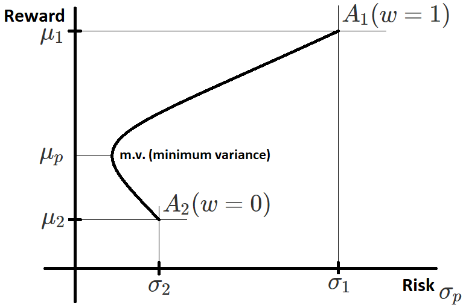

How to choose $w$?

General Case of $N$ assets: $A_1,\cdots,A_N$

$$\mathbf{R}=\left(\begin{array}{c}R_1\\\vdots\\R_N\end{array}\right)$$

$$\boldsymbol{\mu}=\left(\begin{array}{c}\text{E}(R_1)\\\vdots\\\text{E}(R_N)\end{array}\right)=\left(\begin{array}{c}\mu_1\\\vdots\\\mu_N\end{array}\right)$$

$$\Omega=\underbrace{\text{Cov}(\mathbf{R})}_{i,j\text{ -th entry: }\text{Cov}(R_i,R_j)}=\left(\begin{array}{c}
\text{Var}(R_1)&\text{Cov}(R_1,R_2)&\cdots&\text{Cov}(R_1,R_N)\\
\text{Cov}(R_2,R_1)&\text{Var}(R_2)&\cdots&\text{Cov}(R_2,R_N)\\
\vdots&\vdots&\ddots&\vdots\\
\text{Cov}(R_N,R_1)&\text{Cov}(R_N,R_2)&\cdots&\text{Var}(R_N)
\end{array}\right)$$

$R_p=w_1\cdot R_1+\cdots+w_N\cdot R_N=\mathbf{w}^T\cdot\mathbf{R}$ where $\mathbf{w}=\left(\begin{array}{c}{w_1\\\vdots\\w_N}\end{array}\right)$

$\mathbf{w}^T\cdot\mathbf{J}=1$ where $\mathbf{J}=\left(\begin{array}{c}{1\\\vdots\\1}\end{array}\right)$

$\mu_p=\text{E}(R_p)=w_1\cdot\mu_1+\cdots+w_N\cdot\mu_N=\mathbf{w}^T\cdot\boldsymbol{\mu}$

$\sigma_p^2=\mathbf{w}^T\Omega\mathbf{w}$

How to choose $w$?

- Specify $\mu_p$: minimize $\sigma_p^2=\mathbf{w}^T\Omega\mathbf{w}$ subject to $\mathbf{w}^T\cdot\boldsymbol{\mu}=\mu_p$ and $\mathbf{w}^T\cdot\mathbf{J}=1$

**Quadratic Programming**

Given:

- $N\times N$ matrix $D$
- $N\times1$ vector $\mathbf{d}$
- $N\times(m_{\text{eq}}+m_{\text{neq}})$ matrix $A=\left(\begin{array}{c}A_{\text{eq}}&A_{\text{neq}}\end{array}\right)$ where $A_{\text{eq}}$ is the $m_{\text{eq}}$ columns and $A_{\text{neq}}$ is the $m_{\text{neq}}$ columns
- $(m_{\text{eq}}+m_{\text{neq}})\times1$ vector $\mathbf{b}=\left(\begin{array}{c}\mathbf{b}_{\text{eq}}\\\mathbf{b}_{\text{neq}}\end{array}\right)$ where $\mathbf{b}_{\text{eq}}$ is the $m_{\text{eq}}$ rows and $\mathbf{b}_{\text{neq}}$ is the $m_{\text{neq}}$ rows

Find the $N\times1$ vector $\mathbf{x}$ that minimizes $\frac{1}{2}\mathbf{x}^TD\mathbf{x}-\mathbf{d}^T\mathbf{x}$ subject to $A_{\text{eq}}^T\mathbf{x}=\mathbf{b}_{\text{eq}}$ and $A_{\text{neq}}^T\mathbf{x}\geq\mathbf{b}_{\text{neq}}$

Our problem:

- $\mathbf{x}=\mathbf{w}$
- $D=2\Omega$
- $\mathbf{d}=\left(\begin{array}{c}{0\\\vdots\\0}\end{array}\right)=\mathbf{0}_{n\times1}$
- $A=\left(\begin{array}{c}1&\mu_1\\\vdots&\vdots\\1&\mu_N\end{array}\right)$
- $\mathbf{b}=\left(\begin{array}{c}1\\\mu_p\end{array}\right)$

Suppose we want non-negative weights $w_1\geq0,\cdots,w_N\geq0$ use $m_{\text{neq}}=N$, $A=\left(\left.\begin{array}{c}1&\mu_1\\\vdots&\vdots\\1&\mu_N\end{array}\right|I_N\right)$, and $\mathbf{b}_{(N+2)\times1}=\left(\begin{array}{c}{1\\\mu_p\\0\\\vdots\\0}\end{array}\right)$

Thanks to *Zhenjie Shen* for help with the notes.